# Practical Machine Learning Project

Carlos Trejo

Sunday, January 25, 2015

# Activity Recognition of Weight Lifting Exercises

## Summary

The goal of this project is to build a predictive model to assess the quality of execution of weight lifting exercises. Machine learning is used to detect mistakes automatically.

First of all, the files with the training and test set will be loaded and cleaned, in order to select just the useful features for prediction.

Then, we will use the training data to build a prediction model. To estimate model accuracy, k-fold cross validation will be used.

In order to compare results, 2 different models will be built: Trees and random forests.

Finally, we are going to compare the accuracy of the models and use the best to make our final predictions.

# 1. Data preparation

```r
library(caret)
library(Amelia)
```

Load the datafiles:

```r
training <- read.csv('pml-training.csv', na.strings=c("NA","#DIV/0!",""))
test <- read.csv('pml-testing.csv', na.strings=c("NA","#DIV/0!",""))
```

Classe is the target variable, let’s take a look at it.

According to the dataset documentation:

A - Exercise done according to specifications

B - Throwing the elbows to the front

C - Lifting the dumbbell only halfway

D - Lowering the dumbbell only halfway

```r
table(training$classe)
```

```
##
##    A    B    C    D    E
## 5580 3797 3422 3216 3607
```

# 2. Feature Selection

```r
dim(training)
```

```
## [1] 19622   160
```

There are 160 features available. Let’s make a selection of the most useful ones.

We are going to make the same transformations in the testing and the test set.

## a. Get and remove near zero covariates from the data

```r
nzv <- nearZeroVar(training, saveMetrics=TRUE)
training <- training[,-which(nzv$nzv==TRUE)]
test <- test[,-which(nzv$nzv==TRUE)]
dim(training)
```

```
## [1] 19622   124
```

After removing the near zero covariates, we are left with 124 features.

## b. Analyze missing data

Draw a missing map with darkred color for missing values, lightgreen for observed values.

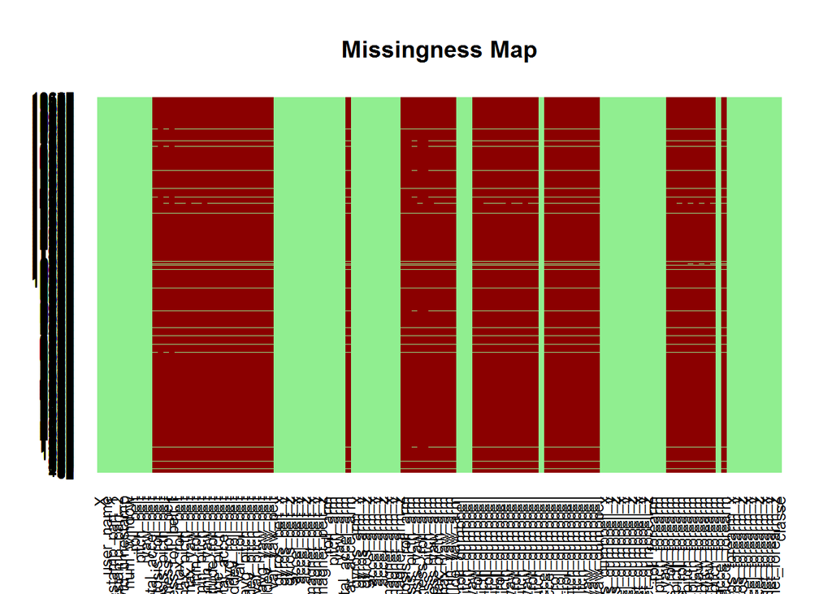

```r
missmap(training, col=c("darkred","lightgreen"), legend=FALSE, rank.order=FALSE)
```

The previous plot shows that there are a lot of almost completely empty (and therefore useless) columns in the dataset, so let’s remove them.

Count the missing values for each column to decide which ones are to be deleted:

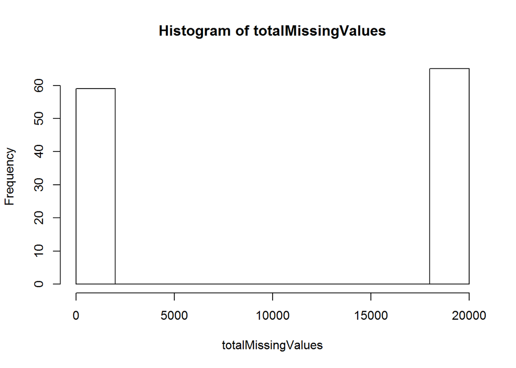

```r
totalMissingValues = sapply(training, function(x) {sum(is.na(x))})
hist(totalMissingValues)
```

Here we can see the useless columns have more than 15,000 missing values, so that’s will be our simple rule to drop columns:

```r
columnsToRemove = names(totalMissingValues[totalMissingValues>15000])
training <- training[,!names(training) %in% columnsToRemove]
test <- test[,!names(test) %in% columnsToRemove]
```

According to the documentation, the first seven variables are related to the subject and some other descriptive values, so we can also leave them out:

```r
training <- training[,-c(1:7)]
test <- test[,-c(1:7)]
dim(training)
```

```
## [1] 19622    52
```

Our final tidy dataset have just the most useful 52 features. Let’s prepare for model creation.

# 2. Train Control

The method we will be using for train control is 10 fold Cross Validation. Also, set the seed for reproducibility reasons:

```r
train_control <- trainControl(method="cv", number=10, allowParallel = TRUE)
set.seed(1234)
```

# 3. Building Predictive Models

Let’s build two different models:

## a. Trees

```r
startTime <- Sys.time()
model1 <- train(classe ~ ., data = training, method = "rpart", trControl = train_control)
endTime <- Sys.time()
model1Time <- endTime - startTime
print(model1Time)
```

```
## Time difference of 37.59 secs
```

```r
round(max(head(model1$results)$Accuracy), 3)
```

```
## [1] 0.514
```

The model used aprox. 37 seconds to run, but the accuracy of the predictions is not good: 51%

## b. Random Forests

```r
startTime <- Sys.time()
model2 <- train(classe ~ ., data = training, method = "rf", trControl = train_control)
endTime <- Sys.time()
model2Time <- endTime - startTime
print(model2Time)
```

```
## Time difference of 41.98 mins
```

```r
round(max(head(model2$results)$Accuracy), 3)
```

```
## [1] 0.995
```

Random fortest yields much better results, so let’s make our predictions based on this model.

# 4. Making Predictions

Make the predictions on the test data:

```r
predictions <- predict(model2, test)
```

Make the files to submit the homework:

```r
pml_write_files = function(x){
  n = length(x)
  for(i in 1:n){
    filename = paste0("problem_id_",i,".txt")
    write.table(x[i],file=filename,quote=FALSE,row.names=FALSE,col.names=FALSE)
  }
}
pml_write_files(predictions)
```

# 5. Results

Random Forests algorithm produced a robust and accurate model. All the prediction submitted for the assignment were correct.